# Regresión no Lineal: splines de regresion

Javier Cara

curso 2018-19

# 1 Polinomios a trozos

- Se divide el rango de *X* por medio de *k* puntos (o nodos), $c_1 < c_2 < \cdots < c_k$.
- En cada intervalo se estima un polinomio de orden *d*.

$$\begin{equation*}
y_i = \left\{
\begin{array}{cl}
\beta_{00} + \beta_{10} x_i + \beta_{20} x_i^2 + \cdots + \beta_{d0} x_i^d + u_i & \text{si } x < c_1,\\
\beta_{01} + \beta_{11} x_i + \beta_{21} x_i^2 + \cdots + \beta_{d1} x_i^d + u_i & \text{si } c_1 \leq x \leq c_2, \\
\beta_{02} + \beta_{12} x_i + \beta_{22} x_i^2 + \cdots + \beta_{d2} x_i^d + u_i & \text{si } c_2 \leq x \leq c_3, \\
\ldots & \ldots, \\
\beta_{0k} + \beta_{1k} x_i + \beta_{2k} x_i^2 + \cdots + \beta_{dk} x_i^d + u_i & \text{si } x \geq c_k, \\
\end{array} \right.
\end{equation*}$$

# 2 Funciones base

Estimar el las ecuaciones anteriores con las restricciones correspondientes puede parecer complicado. Una alternativa es usar *funciones base* para los polinomios. Es fácil comprobar que el siguiente modelo cumple las condiciones de las splines:

$$y_i = \beta_0 + \beta_1 x + \beta_2 x^2 + \cdots + \beta_d x^d + \beta_{d+1} h_1(x) + \cdots + \beta_{d+k} h_k(x) + u_i$$

donde:

$$\begin{equation*}
h_i(x) = \left\{
\begin{array}{cl}
(x - c_i)^d & \text{si } x > c_i,\\
0 & \text{si } x \leq c_i.
\end{array} \right.
\end{equation*}$$

$$p(x) = a_1 b_1(x) + a_2 b_2(x) + \cdots + a_{d+k} b_{d+k}(x)$$

- Esta base no es única. Si conocemos una base para *p(x)* podemos estimar los parámetros utilizando regresión lineal.

# 3 Datos

Datos: Wage

Wage and other data for a group of 3000 male workers in the Mid-Atlantic region.

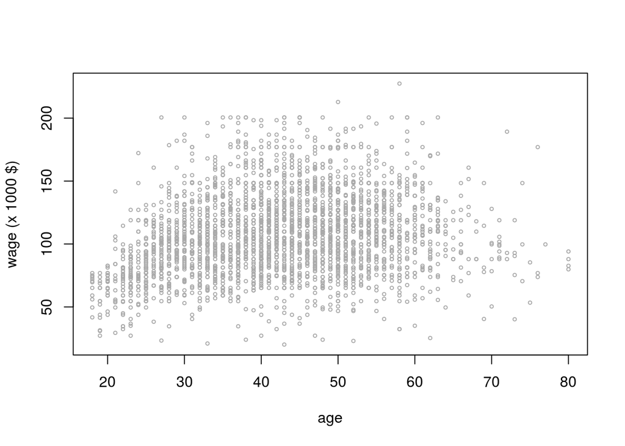

```r
library(ISLR)
datos = Wage
datos = datos[datos$wage<250,]
plot(datos$age,datos$wage, cex = 0.5, col = "darkgrey", ylab = "wage (x 1000 $)", xlab = "age")
```

# 4 Funciones base

```r
library(splines)
```

La función *bs()* define automaticamente una matriz con las funciones de base necesarias a partir de los nodos. Se puede hacer de dos maneras:

- Especificando los nodos:

```r
dim(bs(datos$age, knots = c(25, 40, 60)))
```

```
## [1] 2921    6
```

Tres nodos y splines cúbicos originan una base de tamaño *k+3*!.

```r
# por defecto utiliza splines cubicos
dim(bs(datos$age, knots = c(25, 40, 60), degree = 4))
```

```
## [1] 2921    7
```

- Especificando los grados de libertad:

```r
# k = df - 3, se utilizan quantiles
attr(bs(datos$age, df = 6), "knots")
```

```
## 25% 50% 75%
##  33  42  50
```

```r
attr(bs(datos$age, df = 6, degree = 4), "knots")
```

```
## 33.33333% 66.66667%
##        37        48
```

# 5 Estimacion del modelo

```r
m1 = lm(wage ~ bs(age, knots = c(25, 40, 60)), data = datos)
summary(m1)
```

```
##
## Call:
## lm(formula = wage ~ bs(age, knots = c(25, 40, 60)), data = datos)
##
## Residuals:
##     Min      1Q  Median      3Q     Max
## -93.271 -20.467  -2.006  17.424 116.146
##
## Coefficients:
##                                 Estimate Std. Error t value Pr(>|t|)
## (Intercept)                       59.978      7.151   8.388  < 2e-16 ***
## bs(age, knots = c(25, 40, 60))1    5.534      9.484   0.583 0.559625
## bs(age, knots = c(25, 40, 60))2   44.434      7.280   6.104 1.17e-09 ***
## bs(age, knots = c(25, 40, 60))3   55.949      8.149   6.866 8.04e-12 ***
## bs(age, knots = c(25, 40, 60))4   52.762      8.119   6.498 9.53e-11 ***
## bs(age, knots = c(25, 40, 60))5   40.726     10.942   3.722 0.000201 ***
## bs(age, knots = c(25, 40, 60))6   25.289     14.470   1.748 0.080630 .
## ---
## Signif. codes:  0 '***' 0.001 '**' 0.01 '*' 0.05 '.' 0.1 ' ' 1
##
## Residual standard error: 30.17 on 2914 degrees of freedom
## Multiple R-squared:  0.1096, Adjusted R-squared:  0.1077
## F-statistic: 59.76 on 6 and 2914 DF,  p-value: < 2.2e-16
```

# 6 Prediccion

```r
age_grid = seq(from = min(datos$age), to = max(datos$age), by = 1)
alfa = 0.05
yp = predict(m1, newdata = data.frame(age = age_grid), se = T)
yp1 = yp$fit + qnorm(alfa/2, mean = 0, sd = 1)*yp$se.fit
yp2 = yp$fit + qnorm(1-alfa/2, mean = 0, sd = 1)*yp$se.fit
```

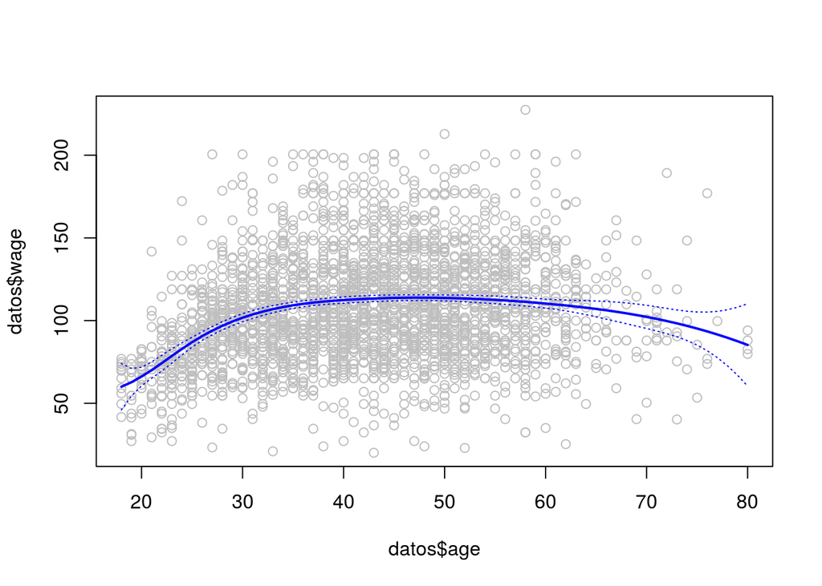

```r
plot(datos$age, datos$wage, col = "gray")
lines(age_grid, yp$fit, col = "blue", lwd = 2)
lines(age_grid, yp1, col = "blue", lty = 3)
lines(age_grid, yp2, col = "blue", lty = 3)
```

# 7 Splines cubicas naturales

- Las splines tienen el problema de que en los extremos las predicciones tienen varianza elevada.
- Esto se debe a que fuera del rango de la variable (valor minimo, valor máximo), la spline es de orden *d*.
- Una opción es obligar a que para valores menores que el mínimo y mayores que el máximo, la spline sea lineal. Esto corrige la varianza alta de los bordes.

$$\begin{equation*}
y_i = \left\{
\begin{array}{cl}
\beta_{00} + \beta_{10} x_i + u_i & \text{si } x < min(x_i),\\
\beta_{00} + \beta_{10} x_i + \beta_{20} x_i^2 + \cdots + \beta_{d0} x_i^d + u_i & \text{si } min(x_i) \leq x \leq c_1, \\
\beta_{01} + \beta_{11} x_i + \beta_{21} x_i^2 + \cdots + \beta_{d1} x_i^d + u_i & \text{si } c_1 \leq x \leq c_2, \\
\ldots & \ldots, \\
\beta_{0k} + \beta_{1k} x_i + \beta_{2k} x_i^2 + \cdots + \beta_{dk} x_i^d + u_i & \text{si } c_k \leq x \leq max(x_i), \\
\beta_{0k} + \beta_{1k} x_i + u_i & \text{si } x \geq max(x_i), \\
\end{array} \right.
\end{equation*}$$
- Luego se añaden *d-2* restricciones en cada uno de los contornos (derivadas 2,3 ,… ,(d-1) = 0), en total, * k + d - 2d + 4 = k - d + 4* funciones base.

- En splines cúbicas, la base tiene tamaño *k+1*.
- En R, se definen splines cúbicas naturales (las splines cúbicas son las más utilizadas) por medio de la función *ns()*.

```r
dim(bs(datos$age, knots = c(25, 40, 60)))
```

```
## [1] 2921    6
```

- Se estima el modelo:

```r
m2 = lm(wage ~ ns(age, knots = c(25, 40, 60)), data = Wage)
summary(m2)
```

```
##
## Call:
## lm(formula = wage ~ ns(age, knots = c(25, 40, 60)), data = Wage)
##
## Residuals:
##     Min      1Q  Median      3Q     Max
## -98.733 -24.761  -5.187  15.216 204.965
##
## Coefficients:
##                                 Estimate Std. Error t value Pr(>|t|)
## (Intercept)                       54.760      5.138  10.658  < 2e-16 ***
## ns(age, knots = c(25, 40, 60))1   67.402      5.013  13.444  < 2e-16 ***
## ns(age, knots = c(25, 40, 60))2   51.383      5.712   8.996  < 2e-16 ***
## ns(age, knots = c(25, 40, 60))3   88.566     12.016   7.371 2.18e-13 ***
## ns(age, knots = c(25, 40, 60))4   10.637      9.833   1.082    0.279
## ---
## Signif. codes:  0 '***' 0.001 '**' 0.01 '*' 0.05 '.' 0.1 ' ' 1
##
## Residual standard error: 39.92 on 2995 degrees of freedom
## Multiple R-squared:  0.08588,    Adjusted R-squared:  0.08466
## F-statistic: 70.34 on 4 and 2995 DF,  p-value: < 2.2e-16
```

```r
ypn = predict(m2, newdata = data.frame(age = age_grid), se = T)
ypn1 = ypn$fit + qnorm(alfa/2, mean = 0, sd = 1)*ypn$se.fit
ypn2 = ypn$fit + qnorm(1-alfa/2, mean = 0, sd = 1)*ypn$se.fit
```

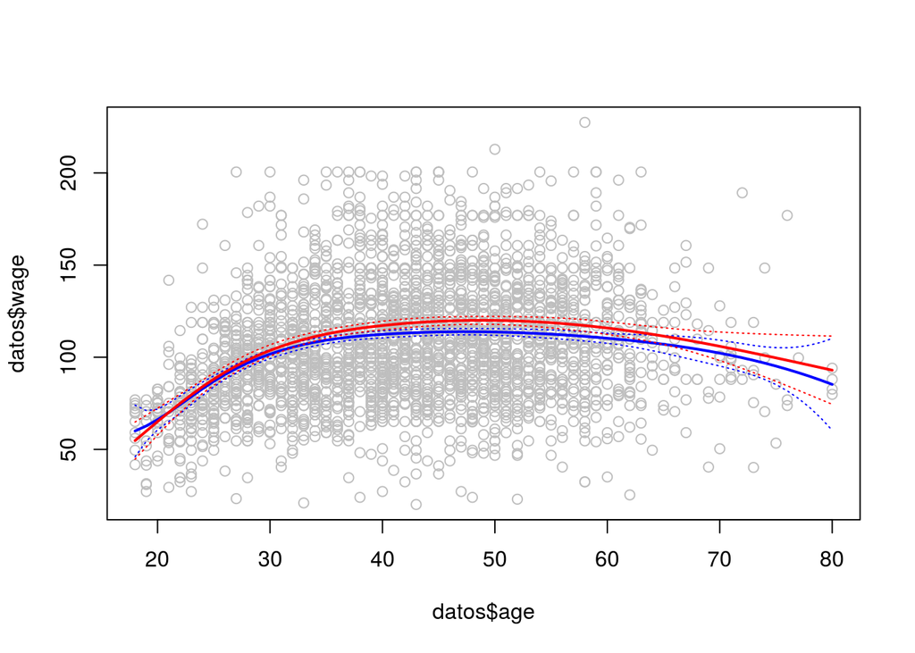

```r
plot(datos$age, datos$wage, col = "gray")
#
lines(age_grid, yp$fit, col = "blue", lwd = 2)
lines(age_grid, yp1, col = "blue", lty = 3)
lines(age_grid, yp2, col = "blue", lty = 3)
#
lines(age_grid, ypn$fit, col = "red", lwd = 2)
lines(age_grid, ypn1, col = "red", lty = 3)
lines(age_grid, ypn2, col = "red", lty = 3)
```

# 8 Seleccion del numero de nodos para splines cubicas

Se van a utilizar splines cubicas.

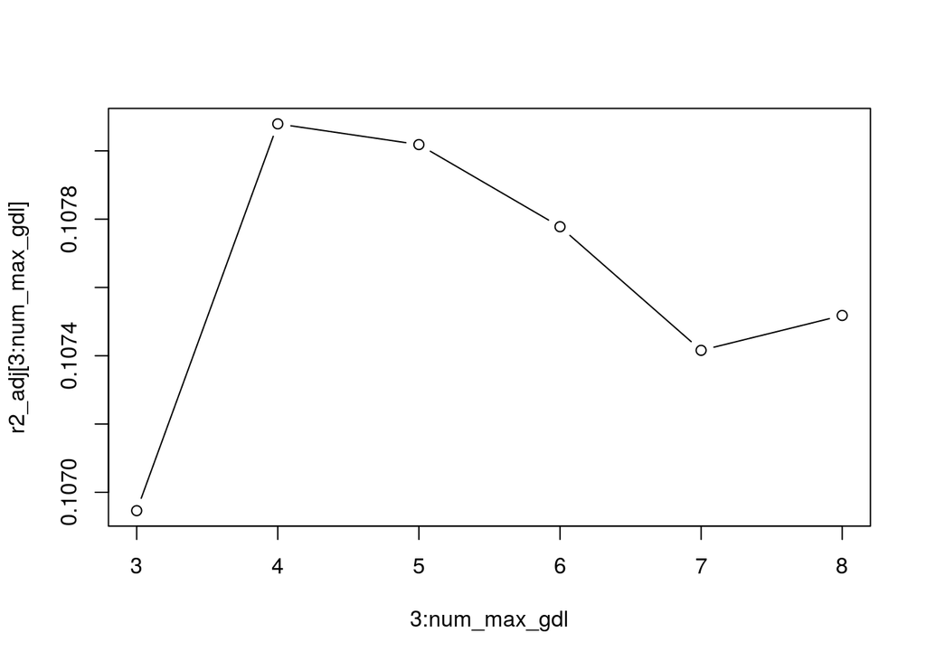

```r
# numero maximo de escalones
num_max_gdl = 8

r2_adj = rep(0, num_max_gdl)
for (i in 3:num_max_gdl){
  m = lm(wage ~ bs(age, df = i), data = datos)
  m_summary = summary(m)
  r2_adj[i] = m_summary$adj.r.squared
}

plot(3:num_max_gdl, r2_adj[3:num_max_gdl], type = "b")
```

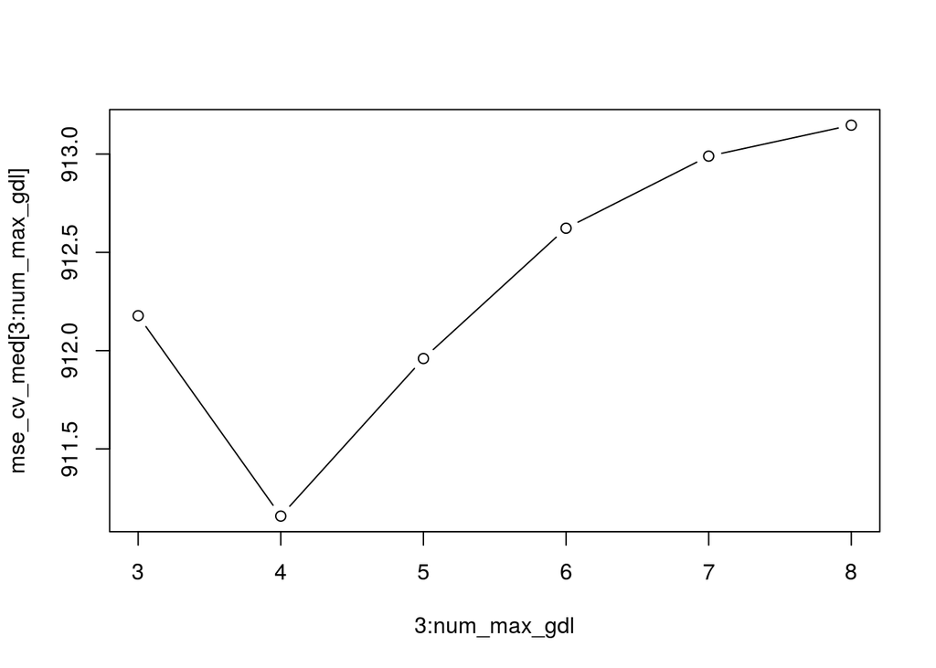

```r
source("cross_val_pos.R")
source("MSE.R")

# datos de los folds
num_folds = 10
# grado de libertad maximo
num_max_gdl = 8
set.seed(1)
pos = cross_val_pos(nrow(datos),num_folds)

mse_cv = matrix(0, nrow = num_folds, ncol = num_max_gdl)
for (i in 1:num_folds){
  # datos de training y de validation de cada fold
  datos_train = datos[pos$train[[i]],]
  datos_test = datos[pos$test[[i]],]

  for (j in 3:num_max_gdl){
    m_cv = lm(wage ~ bs(age, df = j), data = datos_train)
    pred = predict(m_cv, newdata = datos_test)
    mse_cv[i,j] = MSE(datos_test$wage,pred)
  }
}

mse_cv_med = apply(mse_cv, 2, mean)
plot(3:num_max_gdl,mse_cv_med[3:num_max_gdl], type = "b")
```